# Thyroid Carcinoma Final

Rishitha Pulakhandam

2023-12-01

Gene Expression Data Analysis and Visualization Final Project For a final project, you will be conducting an analysis pipeline in attempt to answer some questions about the data set being used. The data selected should include some sort of class structure with different levels (e.g. disease vs. normal, treated vs. non-treated, age<65 vs. age≥65, low dose vs. high dose vs. control etc.). Each project will include analysis of a publicly available data set from some expression database (e.g., Stanford MicroArray Database, Gene Expression Omnibus, EMBL ArrayExpress).

**The Dataset is of the Thyroid Carcinoma - with samples of two dieases states, which are papillary thyroid Carcinoma and Anaplastic thyroid Carcinoma** Dataset-https://www.ncbi.nlm.nih.gov/geo/query/acc.cgi?acc=GSE55933

```r
#Download the Dataset of Thyroid Carcinoma
data_rna <- read.table("/Users/rishithapulakhandam/Downloads/GSE55933_series_matrix.txt",header = TRUE,row.names = 1)
head(data_rna)
```

```
##          GSM1348733 GSM1348734 GSM1348735 GSM1348736 GSM1348737 GSM1348738
## 10338001   13.20795   12.96548   13.08575   13.10394   12.81303   13.09816
## 10338002    6.29508    6.10730    6.22495    6.20104    6.48028    6.14935
## 10338003   11.72879   11.30644   11.53759   11.59795   11.26883   11.52099
## 10338004   11.12372   10.58473   10.73617   10.78646   10.35372   10.83260
## 10338005    3.21449    3.18546    3.19694    3.21917    3.15195    3.22686
## 10338006    3.38037    3.34547    3.37640    3.41477    3.35420    3.38070
##          GSM1348739 GSM1348740 GSM1348741 GSM1348742
## 10338001   13.00234   12.59680   13.20053   12.48912
## 10338002    6.24241    6.42128    6.15844    6.43732
## 10338003   11.45505   10.99189   11.78358   10.78856
## 10338004   10.85718   10.26600   11.14732   10.08210
## 10338005    3.21997    3.18262    3.23225    3.21347
## 10338006    3.41088    3.35889    3.37550    3.43279
```

```r
dim(data_rna)
```

```
## [1] 35556    10
```

**The coloumns are labelled based on the Sample state**

```r
# labeling the header of the dataset
column_name <- colnames(data_rna)
print(column_name)
```

```
##  [1] "GSM1348733" "GSM1348734" "GSM1348735" "GSM1348736" "GSM1348737"
##  [6] "GSM1348738" "GSM1348739" "GSM1348740" "GSM1348741" "GSM1348742"
```

```r
new_col_names <- character(length(column_name))

for (i in 1:10) {
  if (i <= 5) {
    new_col_names[i] <- paste0(column_name[i], "_Papillary")
  } else {
    new_col_names[i] <- paste0(column_name[i], "_Anaplastic")
  }
}

colnames(data_rna) <- new_col_names
print(colnames(data_rna))
```

```
##  [1] "GSM1348733_Papillary"  "GSM1348734_Papillary"  "GSM1348735_Papillary"
##  [4] "GSM1348736_Papillary"  "GSM1348737_Papillary"  "GSM1348738_Anaplastic"
##  [7] "GSM1348739_Anaplastic" "GSM1348740_Anaplastic" "GSM1348741_Anaplastic"
## [10] "GSM1348742_Anaplastic"
```

**A MA plot of the Original Data is plotted**

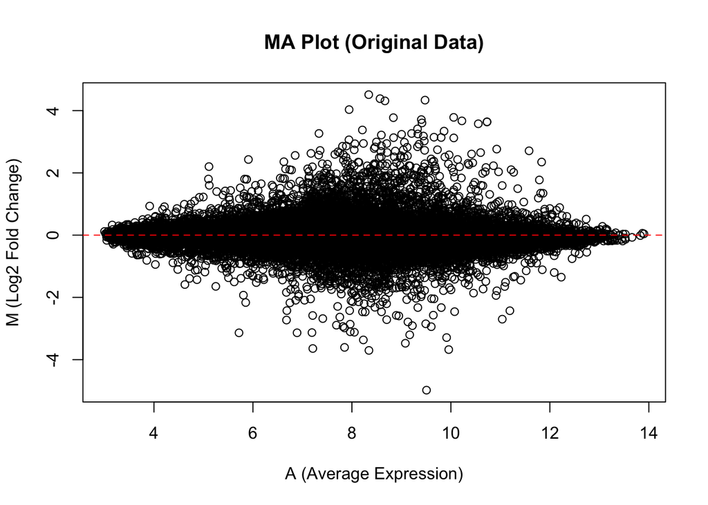

```r
#Plotting a MA plot of the Original data
# Columns 1 to 5 are Papillary Thyroid Carcinoma samples, and columns 6 to 9 are Anaplastic Thyroid Carcinoma samples
library(limma)
# Calculate log2 fold change (M) and average expression (A)
log2_fc <- rowMeans(data_rna[, 1:5]) - rowMeans(data_rna[, 6:10])
average_expr <- (rowMeans(data_rna[, 1:5]) + rowMeans(data_rna[, 6:10])) / 2

# Create MA plot
plot(average_expr, log2_fc, main = "MA Plot (Original Data)", xlab = "A (Average Expression)", ylab = "M (Log2 Fold Change)")

# Add a horizontal line at y = 0
abline(h = 0, col = "red", lty = 2)
```

The student should first test for outlier samples and provide visual proof. Remove these outliers.

**The data subjected various forms of Normalization such as Quantile Normalization ,Scale Normalization, Global Normalization.**

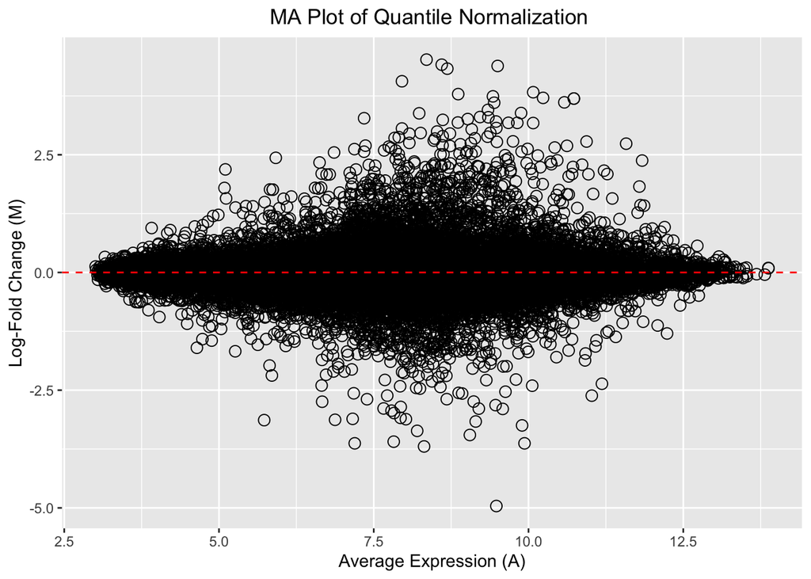

```r
library(limma)
#Sample wise normalization
#Quantile Normalization
normalized_data_median <- normalizeQuantiles(data_rna)

#Columns 1 to 5 are Papillary Thyroid Carcinoma samples and columns 6 to 9 are Anaplastic Thyroid Carcinoma samples

# Calculate log-fold change (M)
log_fold_change <- rowMeans(normalized_data_median[, 1:5]) - rowMeans(normalized_data_median[, 6:10])

# Calculate average expression (A)
average_expression <- rowMeans(normalized_data_median[, 1:10])

# Create a data frame for plotting
plot_data <- data.frame(M = log_fold_change, A = average_expression)

# Plotting
library(ggplot2)

# plot_data contains columns A and M
ggplot(plot_data, aes(x = A, y = M)) +
  geom_point(shape = 1, size = 3) +
  geom_hline(yintercept = 0, linetype = "dashed", color = "red") +
  labs(title = "MA Plot of Quantile Normalization ", x = "Average Expression (A)", y = "Log-Fold Change (M)") +
  theme(plot.title = element_text(hjust = 0.5))  # Center align the title
```

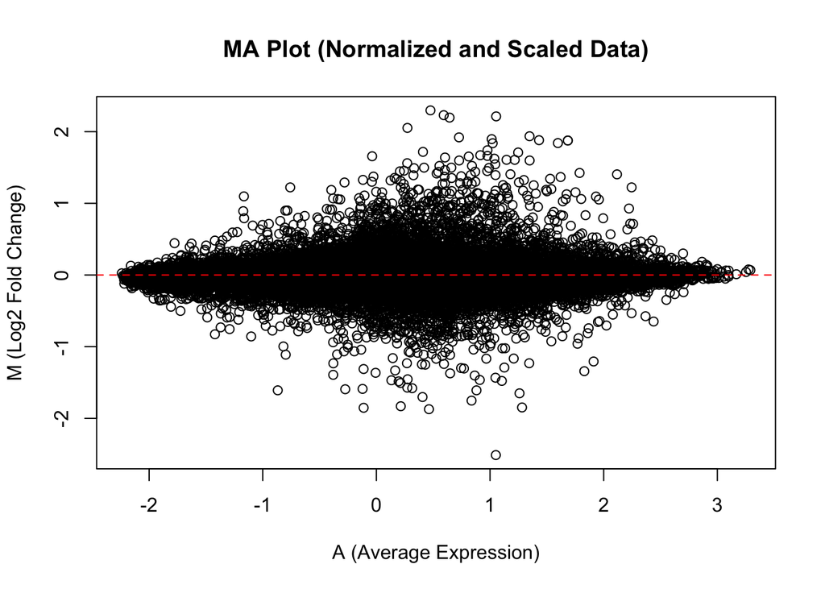

```r
# Scale normalization
library(limma)
normalized_data_scale <- scale(data_rna)


# Columns 1 to 5 are Papillary Thyroid Carcinoma samples, and columns 6 to 10 are Anaplastic Thyroid Carcinoma samples

# Calculate log2 fold change (M) and average expression (A)
log2_fc <- rowMeans(normalized_data_scale[, 1:5]) - rowMeans(normalized_data_scale[, (ncol(normalized_data_scale)-4):ncol(normalized_data_scale)])
average_expr <- (rowMeans(normalized_data_scale[, 1:5]) + rowMeans(normalized_data_scale[, (ncol(normalized_data_scale)-4):ncol(normalized_data_scale)])) / 2

# Create MA plot
plot(average_expr, log2_fc, main = "MA Plot (Normalized and Scaled Data)", xlab = "A (Average Expression)", ylab = "M (Log2 Fold Change)")

# Add a horizontal line at y = 0
abline(h = 0, col = "red", lty = 2)
```

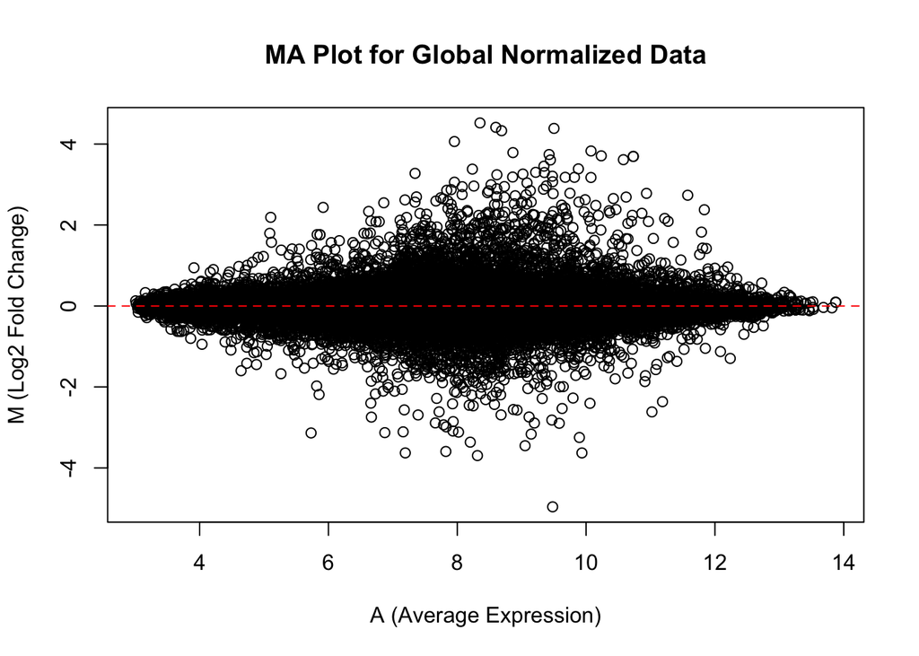

```r
#Global Normalization
library(limma)
global_normalized_data <- normalizeBetweenArrays(as.matrix(data_rna))

# Calculate log2 fold change (M) and average expression (A)
log2_fc <- rowMeans(global_normalized_data[, 1:5]) - rowMeans(global_normalized_data[, 6:10])
average_ex <- rowMeans(cbind(global_normalized_data[, 1:5], global_normalized_data[, 6:10]))

# Create MA plot
plot(average_ex, log2_fc, main = "MA Plot for Global Normalized Data",
     xlab = "A (Average Expression)", ylab = "M (Log2 Fold Change)")

# Add a horizontal line at y = 0
abline(h = 0, col = "red", lty = 2)
```

**Data is checked for NA values.**

```r
#imputation
#check for NA
missing_values <- any(is.na(normalized_data_median))
missing_values
```

```
## [1] FALSE
```

```r
# omitting NA values
data_rna <- na.omit(normalized_data_median)
```

**Various Visualizations are done to identify Outliners.**

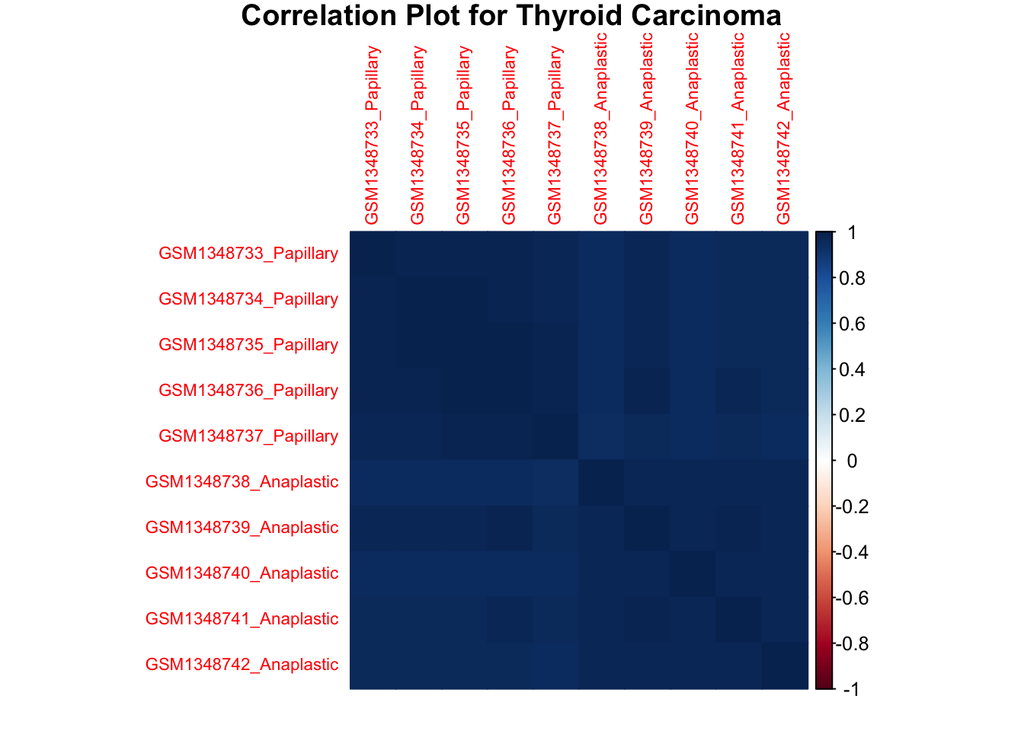

```r
# Visualizing to check for outliners
# CORRELATION PLOT
library(corrplot)
correlation_matrix <- cor(normalized_data_median)
corrplot(correlation_matrix, method = "color",
title = "Correlation Plot for Thyroid Carcinoma", tl.cex = 0.7,
cl.cex = 0.8,
addrect = 2,
rect.col = "black", mar = c(1, 1, 1, 1))
```

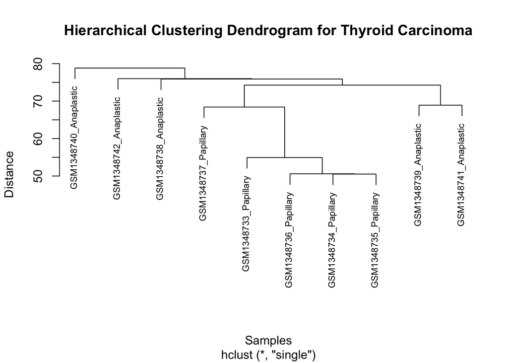

```r
#DENDROGRAM
data_rna_t <- t(normalized_data_median)
data.dist <- dist(data_rna_t,method="euclidean")
data.clust <- hclust(data.dist,method = "single")
plot(data.clust,main = "Hierarchical Clustering Dendrogram for Thyroid Carcinoma", xlab = "Samples", ylab = "Distance",labels=new_col_names,cex=0.75)
```

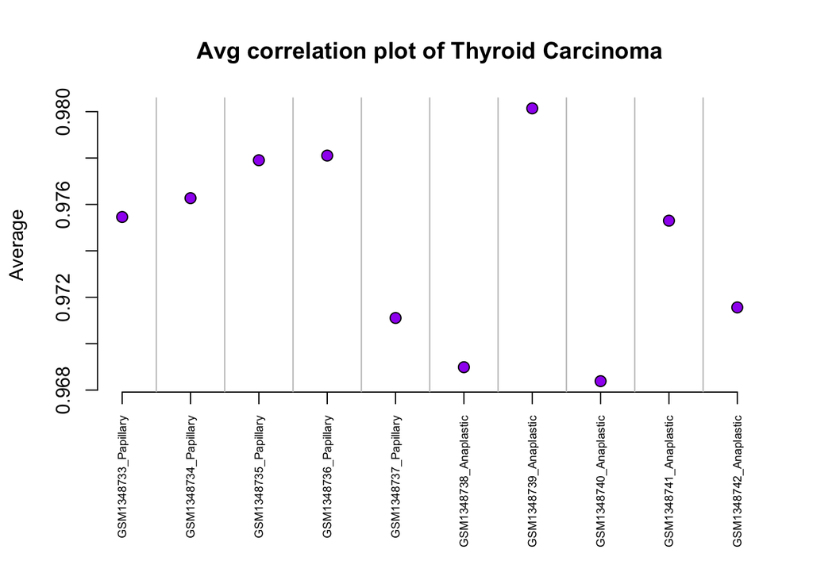

```r
#AVERAGE CORRELATION PLOT
dat.avg <- apply(correlation_matrix, 1, mean)
par(oma = c(3, 0.1, 0.1, 0.1))
plot(c(1, length(dat.avg)), range(dat.avg), type = "n", xlab = "", ylab = "Average", main = "Avg correlation plot of Thyroid Carcinoma", axes = F)
points(dat.avg, bg = "purple", col = 1, pch = 21, cex = 1.25)
axis(1, at = c(1:length(dat.avg)), labels = dimnames(normalized_data_median)[[2]], las = 2, cex.lab = 0.4, cex.axis = 0.6)
axis(2)
abline(v = seq(0.5, 62.5, 1), col = "grey")
```

**Samples “GSM1348740_Anaplastic” and “GSM1348738_Anaplastic” are identified as Outliners.**

```r
# Removing the Outliners
data_rna_no_outliners <- subset (data_rna, select = -c(GSM1348740_Anaplastic,GSM1348738_Anaplastic))
dim(data_rna_no_outliners)
```

```
## [1] 35556     8
```

```r
head(data_rna_no_outliners)
```

```
##          GSM1348733_Papillary GSM1348734_Papillary GSM1348735_Papillary
## 10338001            13.282476            12.969022            13.119797
## 10338002             6.249707             6.074157             6.199358
## 10338003            11.746826            11.294599            11.552411
## 10338004            11.180234            10.576274            10.769686
## 10338005             3.201410             3.188769             3.184650
## 10338006             3.355995             3.322706             3.391768
##          GSM1348736_Papillary GSM1348737_Papillary GSM1348739_Anaplastic
## 10338001            13.147034            12.855942             13.015949
## 10338002             6.181169             6.473126              6.260732
## 10338003            11.616831            11.356152             11.438572
## 10338004            10.808376            10.420210             10.833634
## 10338005             3.212376             3.193787              3.222566
## 10338006             3.413083             3.418650              3.408481
##          GSM1348741_Anaplastic GSM1348742_Anaplastic
## 10338001             13.303405             12.404126
## 10338002              6.102194              6.546061
## 10338003             11.801071             10.732180
## 10338004             11.149844             10.025357
## 10338005              3.219192              3.216851
## 10338006              3.358746              3.445249
```

**Quantile Normalization is performed after removing the outliners.**

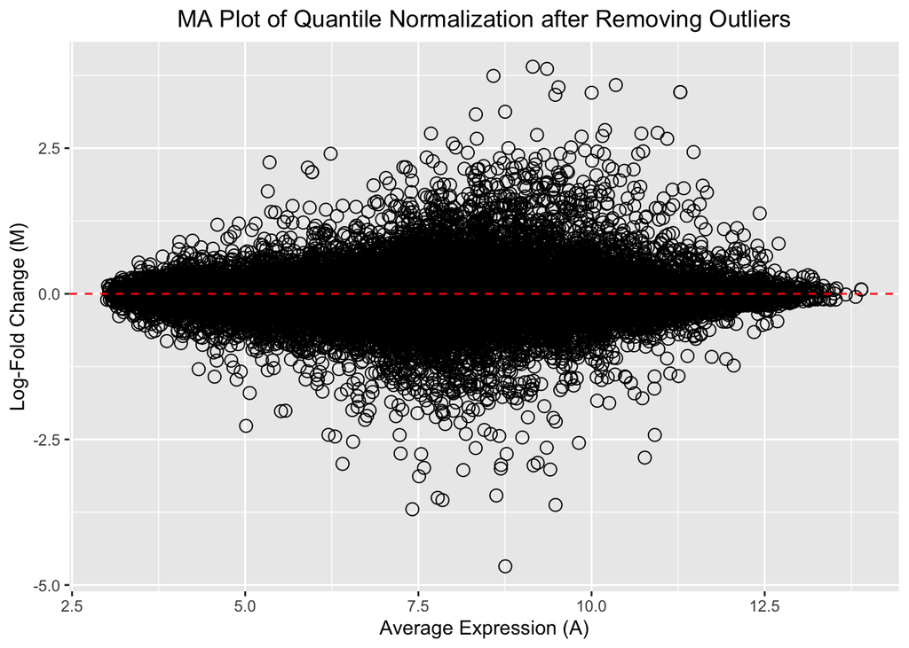

```r
#Normalizing after removing Outliners
#Quantile Normalization
normalized_data_rna <- normalizeQuantiles(data_rna_no_outliners)

# columns 1 to 5 are Papillary Thyroid Carcinoma samples and columns 6 to 9 are Anaplastic Thyroid Carcinoma samples

# Calculate log-fold change (M)
log_fold_change <- rowMeans(data_rna_no_outliners[, 1:5])- rowMeans(data_rna_no_outliners[, 6:8])

# Calculate average expression (A)
avg_expression <- rowMeans(data_rna_no_outliners[, 1:8])

# Create a data frame for plotting
plot_MA_data <- data.frame(M = log_fold_change, A = avg_expression)

# Plotting
library(ggplot2)

ggplot(plot_MA_data, aes(x = A, y = M)) +
  geom_point(shape = 1, size = 3) +
  geom_hline(yintercept = 0, linetype = "dashed", color = "red") +
  labs(title = "MA Plot of Quantile Normalization after Removing Outliers",
       x = "Average Expression (A)", y = "Log-Fold Change (M)") +
  theme(plot.title = element_text(hjust = 0.5))
```

Then, filter out genes that have low expression values using some criterion.

```r
# Removing genes under the 25th quatile,Removing low-expressed genes can help reduce the dimensionality of the dataset, making it more computationally efficient and improving the interpretability of results.

data_rna <- apply(normalized_data_rna, 1, var)
head((data_rna),30)
```

```
##     10338001     10338002     10338003     10338004     10338005     10338006
## 0.0832244604 0.0280727932 0.1139214661 0.1446901303 0.0002172788 0.0016166090
##     10338007     10338008     10338009     10338010     10338011     10338012
## 0.0026495238 0.0038389070 0.0464898254 0.0004475374 0.0167874282 0.0007419395
##     10338013     10338014     10338015     10338016     10338017     10338018
## 0.0003111690 0.0002061418 0.0002109433 0.0361986859 0.0535607293 0.0355449396
##     10338019     10338020     10338021     10338022     10338023     10338024
## 0.0176179375 0.0353401860 0.0018638344 0.0013388389 0.0045746715 0.0424896168
##     10338025     10338026     10338027     10338028     10338029     10338030
## 0.1389000850 0.0346861774 0.0421450898 0.0110112783 0.1899350215 0.0001887905
```

```r
# Determine the threshold as the top 75% of variances
threshold <- quantile(data_rna, 0.25)  # Replace 'variance_values' with your actual variance values

# Filter genes with variances above the threshold
filtered_genes <- data_rna[data_rna >= threshold]
length(filtered_genes)
```

```
## [1] 26667
```

```r
head((names(filtered_genes)),10)
```

```
##  [1] "10338001" "10338002" "10338003" "10338004" "10338009" "10338011"
##  [7] "10338016" "10338017" "10338018" "10338019"
```

```r
genes_above_threshold <- names(filtered_genes)
filtered_data <- normalized_data_rna[genes_above_threshold,]
dim(filtered_data)
```

```
## [1] 26667     8
```

Next, conduct some method of feature selection with a statistical test or other machine learning method. The type of test will depend upon how many factor levels are included in your data set. For example. two conditions would require a two-sample test, while greater than two conditions would require other tests. Adjust for multiplicity, then provide the number of genes retained with the associated score (p-value, weight, test statistic, etc.) and threshold value that you used.

**A Student t-test is done for the Feature Analysis.**

```r
#Student t-test
log2_carcinoma_data <- log2(filtered_data)
t.test.all.genes <- function(x,s1,s2) {
  x1 <- x[s1]
  x2 <- x[s2]
  x1 <- as.numeric(x1)
  x2 <- as.numeric(x2)
  t.out <- t.test(x1,x2, alternative="two.sided",var.equal=T)
  out <- as.numeric(t.out$p.value)
  return(out)
}
pv <- apply(log2_carcinoma_data,1,t.test.all.genes,s1=1:5,s2=6:8)

adjusted_p_values <- p.adjust(pv, method = "BH")
threshold <- 0.05
significant_genes <- (adjusted_p_values <= threshold)
sum(significant_genes)
```

```
## [1] 1902
```

**1902 Significant genes are found**

Plot the scores of those genes retained in a histogram.

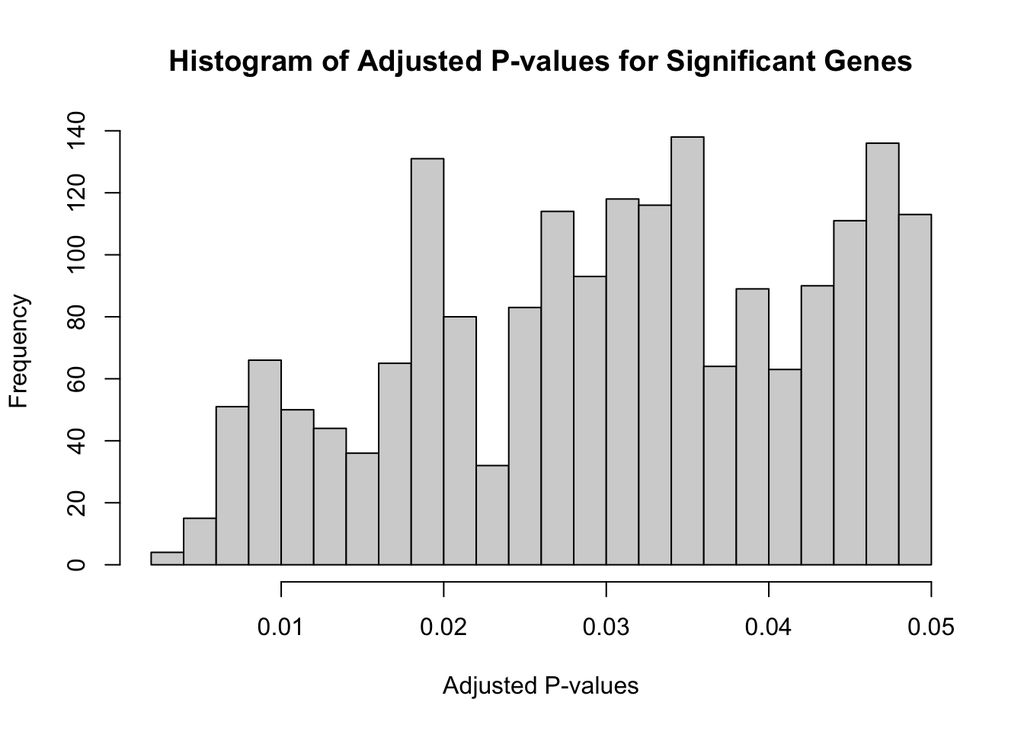

```r
# Histogram
hist(adjusted_p_values[significant_genes], breaks = 30, xlab = "Adjusted P-values", main = "Histogram of Adjusted P-values for Significant Genes")
```

Next, subset your data by the genes that you determined

```r
# Subset significant genes to a new dataset
significant_genes_data <- log2_carcinoma_data[significant_genes, , drop = FALSE]

# The new dataset of significant genes
head(significant_genes_data)
```

```
##          GSM1348733_Papillary GSM1348734_Papillary GSM1348735_Papillary
## 10338150             3.453489             3.423948             3.429255
## 10338216             3.020751             3.038547             3.070417
## 10338333             3.541385             3.536555             3.528778
## 10338400             3.566876             3.540804             3.554395
## 10338493             3.278739             3.297799             3.286639
## 10338509             3.343039             3.367033             3.350209
##          GSM1348736_Papillary GSM1348737_Papillary GSM1348739_Anaplastic
## 10338150             3.447129             3.409495              3.379959
## 10338216             3.033611             3.064509              3.112964
## 10338333             3.532466             3.463963              3.442130
## 10338400             3.581125             3.532559              3.466658
## 10338493             3.299350             3.316432              3.181873
## 10338509             3.341166             3.294452              3.252815
##          GSM1348741_Anaplastic GSM1348742_Anaplastic
## 10338150              3.340588              3.366031
## 10338216              3.145745              3.122532
## 10338333              3.401878              3.426507
## 10338400              3.430397              3.417330
## 10338493              3.188649              3.134542
## 10338509              3.261185              3.204852
```

and use one of the clustering or dimensionality reduction methods discussed in class to visualize the samples in two-dimensional space (xy scatter plot, dendrogram, etc.). Using these linear projections of the original data (i.e. cluster centroids, latent variables, etc.), use a classification method to classify the samples into their respective classes. Make sure to color the samples appropriately by their predicted class membership and use different symbols for the actual class memberships. **Confirmational Analysis**

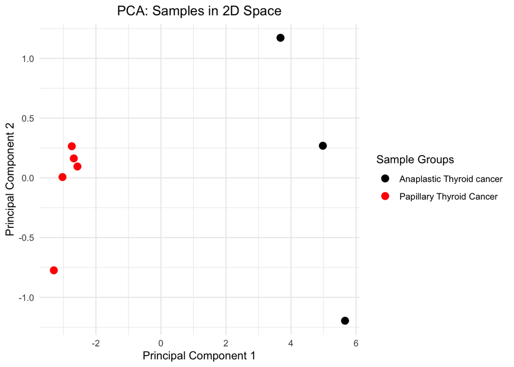

```r
# Perform PCA for dimensionality reduction
pca_result <- prcomp(t(significant_genes_data))  # Transpose data for samples as rows
pca_scores <- pca_result$x

# Plot PCA scores with color based on sample groups
# Define sample group vector
num_papillary_samples <- 5  # Number of papillary thyroid Carcinoma samples
num_anaplastic_samples <- 8 - num_papillary_samples  # Number of anaplastic thyroid Carcinoma samples
sample_groups <- factor(c(rep("Papillary Thyroid Cancer", num_papillary_samples), rep("Anaplastic Thyroid cancer", num_anaplastic_samples)))

library(ggplot2)

# Combine PCA scores and sample groups into a data frame
pca_data <- cbind.data.frame(pca_scores, Sample_Group = sample_groups)

# Create a PCA plot with ggplot2
# Plot PCA scores with color based on sample groups
ggplot(pca_data, aes(x = PC1, y = PC2, color = Sample_Group)) +
  geom_point(size = 3) +
  labs(x = "Principal Component 1", y = "Principal Component 2") +
  ggtitle("PCA: Samples in 2D Space") +
  theme_minimal() +
  scale_color_manual(values = c("black", "red")) +
  theme(legend.position = "right",  # Keep legend on the right
        plot.title = element_text(hjust = 0.5)) +
  guides(color = guide_legend(title = "Sample Groups"))
```

**KNN Classification is performed**

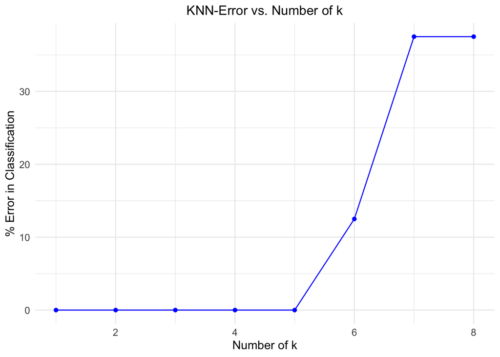

```r
set.seed(100)
library(class)
library(ggplot2)

error_list <- NULL

# Loop through different values of k (neighbors)
for (i in 1:8) {
  # Perform k-NN classification
  dat_knn <- knn(t(significant_genes_data), t(significant_genes_data), sample_groups, k = i, prob = TRUE)

  # Calculate error rate
  er_total <- sum(dat_knn != sample_groups) / length(sample_groups) * 100  # Total error rate

  # Store error rate in the list
  error_list <- c(error_list, round(er_total, 1))
}

# Create a data frame for ggplot
k_values <- 1:8
error_df <- data.frame(k = k_values, error_rate = error_list)

# Plot classification error vs. k using ggplot
ggplot(error_df, aes(x = k, y = error_rate)) +
  geom_line(color = "blue") +
  geom_point(color = "blue") +
  labs(x = "Number of k", y = "% Error in Classification") +
  theme_minimal() +
  theme(axis.text = element_text(size = 10), axis.title = element_text(size = 12),
        plot.title = element_text(hjust = 0.5)) +
  ggtitle("KNN-Error vs. Number of k")
```

**The K value is taken as 3.**

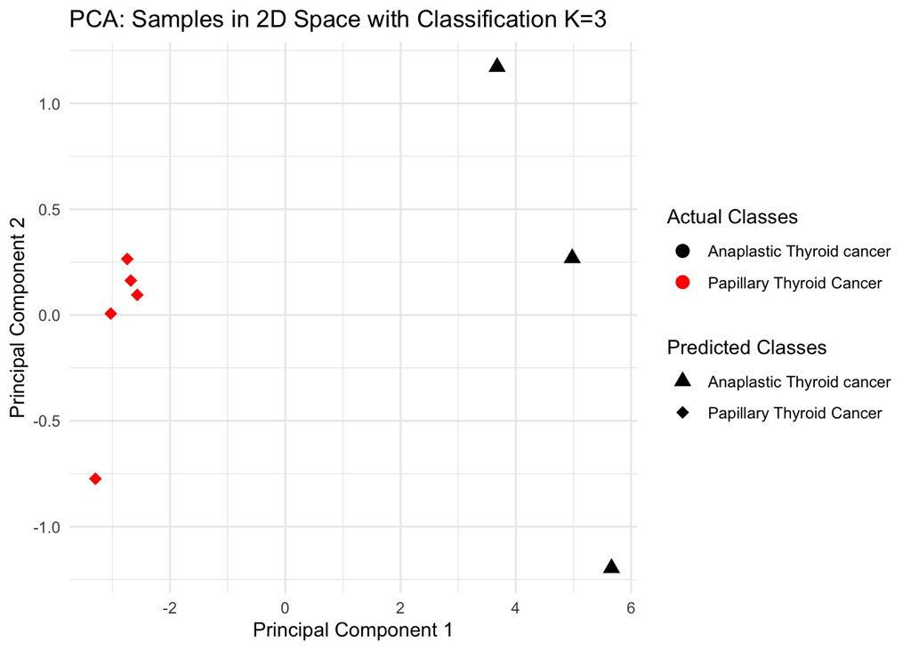

```r
# selected_genes_data is a dataset with selected genes
# Perform PCA for dimensionality reduction
pca_result <- prcomp(t(significant_genes_data))
pca_scores <- pca_result$x

# Use k-NN for classification (you can choose other classifiers)
# K value is taken as 3
library(class)
k <- 3
knn_model <- knn(pca_scores, pca_scores, cl = sample_groups, k = k)
predicted_classes <- knn_model

# Visualize results
library(ggplot2)
results_data <- cbind.data.frame(pca_scores, Actual_Class = sample_groups, Predicted_Class = predicted_classes)

# Visualize results with red triangle for Papillary and black square for Anaplastic
ggplot(results_data, aes(x = PC1, y = PC2, color = Actual_Class, shape = Predicted_Class)) +
  geom_point(size = 3) +
  labs(x = "Principal Component 1", y = "Principal Component 2") +
  ggtitle("PCA: Samples in 2D Space with Classification K=3") +
  theme_minimal() +
  scale_color_manual(values = c("black", "red")) +
  scale_shape_manual(values = c(17, 18)) +  # 16 for square (Anaplastic), 17 for triangle (Papillary)
  theme(legend.position = "right") +
  guides(color = guide_legend(title = "Actual Classes"), shape = guide_legend(title = "Predicted Classes"))
```

**The K value is taken as 7**

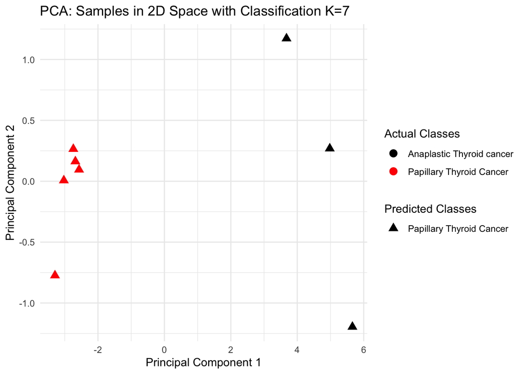

```r
# selected_genes_data is a dataset with selected genes
# Perform PCA for dimensionality reduction
pca_result <- prcomp(t(significant_genes_data))
pca_scores <- pca_result$x

# Use k-NN for classification (you can choose other classifiers)
#K value is taken as 7
library(class)
k <- 7
knn_model <- knn(pca_scores, pca_scores, cl = sample_groups, k = k)
predicted_classes <- knn_model

# Visualize results
library(ggplot2)
results_data <- cbind.data.frame(pca_scores, Actual_Class = sample_groups, Predicted_Class = predicted_classes)

# Visualize results with red triangle for Papillary and black square for Anaplastic
ggplot(results_data, aes(x = PC1, y = PC2, color = Actual_Class, shape = Predicted_Class)) +
  geom_point(size = 3) +
  labs(x = "Principal Component 1", y = "Principal Component 2") +
  ggtitle("PCA: Samples in 2D Space with Classification K=7") +
  theme_minimal() +
  scale_color_manual(values = c("black", "red")) +
  scale_shape_manual(values = c(17, 18)) +  # 16 for square (Anaplastic), 17 for triangle (Papillary)
  theme(legend.position = "right") +
  guides(color = guide_legend(title = "Actual Classes"), shape = guide_legend(title = "Predicted Classes"))
```

Finally, using the top 5 discriminant genes (positive and negative direction) from your analysis, go to NCBI’s DAVID and look up the gene information. Provide the gene name and functional information (associated pathways, GO terms, etc) for these 10 genes.

**The top discriminant genes are found.**

```r
# Top 5 discriminant genes
ann.dat2<-colnames(significant_genes_data)
ann.dat2 <- ifelse(grepl("_Papillary", ann.dat2), 0, 1)
ann.dat2 <- as.factor(ann.dat2)
library(limma)

design_matrix <- model.matrix(~ann.dat2)
fit <- lmFit(significant_genes_data, design_matrix)
fit_ebayes <- eBayes(fit)
genes<- topTable(fit_ebayes, coef = "ann.dat21", sort.by = "t")
#Positive Direction
top_positive_genes <- genes[order(abs(genes$t)), ][1:5, ]
#Negative Direction
top_negative_genes <- genes[order(-abs(genes$t)), ][1:5, ]

print(top_positive_genes)
```

```
##              logFC  AveExpr        t      P.Value    adj.P.Val        B
## 10513256 0.2618128 3.118836 15.61366 1.238916e-07 2.237101e-05 8.399966
## 10514340 0.2245504 2.824383 16.16801 9.246690e-08 1.954134e-05 8.687350
## 10473312 0.5274756 2.832809 16.17815 9.198173e-08 1.954134e-05 8.692497
## 10448016 0.2703771 3.056021 16.18301 9.175026e-08 1.954134e-05 8.694962
## 10501164 0.3100228 3.081964 16.40949 8.164284e-08 1.954134e-05 8.808967
```

```r
print(top_negative_genes)
```

```
##               logFC  AveExpr         t      P.Value    adj.P.Val         B
## 10554156 -0.2968860 3.171598 -21.69233 7.706142e-09 1.465708e-05 11.023828
## 10468992  0.2492291 3.087346  18.90357 2.476211e-08 1.875015e-05  9.951709
## 10462702  0.3181248 2.947001  18.51070 2.957437e-08 1.875015e-05  9.784389
## 10506680  0.2210579 2.838008  17.06615 5.869517e-08 1.954134e-05  9.129277
## 10456071  0.1989373 3.351936  17.01803 6.010719e-08 1.954134e-05  9.106305
```

**Identifying genes that are differentially expressed without necessarily distinguishing between upregulation and downregulation, thats why I have taken the absolute values.The Data set has samples from papillary thyroid carcinoma and Anaplastic Thyroid carcinoma, the paper tried to record the Papillary Thyroid Carcinoma evolving into a Anaplastic Thyroid Carcinoma.**

**The Gene Symbol and Gene Description is found.**

```r
# Top Positive Genes
top_positive_genes_table <- data.frame(
  GENE_ID = c(10513256, 10514340, 10473312, 10448016, 10501164),
  GENE_SYMBOL = c("PTT_12697", "PTT_18434", "PSEBR_a4163", "parB", "DICPUDRAFT_97663"),
  GENE_DESCRIPTION = c("Hypothetical protein", "Hypothetical protein", "Sulfate ABC transporter periplasmic protein", "ParB family chromosome partitioning protein", "Uncharacterized protein")
)

# Top Negative Genes
top_negative_genes_table <- data.frame(
  GENE_ID = c(10554156, 10468992, 10462702, 10506680, 10456071),
  GENE_SYMBOL = c("wtpA", "PSEBR_a159", "istA", "DICPUDRAFT_148547", "MDS_1287"),
  GENE_DESCRIPTION = c("Tungstate ABC transporter substrate-binding protein WtpA", "Hypothetical protein", "IS21 family transposase", "Uncharacterized protein", "Alpha/beta fold family hydrolase-like protein")
)

# Print tables
print("\nTop Positive Genes:\n")
```

```
## [1] "\nTop Positive Genes:\n"
```

```r
print(top_positive_genes_table)
```

```
##    GENE_ID      GENE_SYMBOL                            GENE_DESCRIPTION
## 1 10513256        PTT_12697                        Hypothetical protein
## 2 10514340        PTT_18434                        Hypothetical protein
## 3 10473312      PSEBR_a4163 Sulfate ABC transporter periplasmic protein
## 4 10448016             parB ParB family chromosome partitioning protein
## 5 10501164 DICPUDRAFT_97663                     Uncharacterized protein
```

```r
print("\nTop Negative Genes:\n")
```

```
## [1] "\nTop Negative Genes:\n"
```

```r
print(top_negative_genes_table)
```

```
##    GENE_ID       GENE_SYMBOL
## 1 10554156              wtpA
## 2 10468992        PSEBR_a159
## 3 10462702              istA
## 4 10506680 DICPUDRAFT_148547
## 5 10456071          MDS_1287
##                                           GENE_DESCRIPTION
## 1 Tungstate ABC transporter substrate-binding protein WtpA
## 2                                     Hypothetical protein
## 3                                  IS21 family transposase
## 4                                  Uncharacterized protein
## 5            Alpha/beta fold family hydrolase-like protein
```